# Decision Tree

Jack Julian and Seth Grace

2025-11-08

# Read in the data

The following dataset will be used to predict `loan_default`.

```r
holdout.df=readRDS("M:/MSBA/ISA 591/Holdout_cleaned.RDS")
df=readRDS("M:/MSBA/ISA 591/EDA_cleaned.RDS")
# target smaller sample size, e.g., 25,000 rows total
set.seed(123)
train.smaller <- df %>%
  dplyr::sample_n(25000)

table(train.smaller$loan_default)
```

```
##
##    No   Yes
## 20128  4872
```

We elected to downsample to 25,000 observations due to issues with computational power. By reducing to 25,000 observations we increase the bias and possibly the variance as well. It is a potentially risky move however, given our processing power we elected to move forward with it.

# Decision Tree

[figure not shown]

```r
library(rpart)
library(rpart.plot)

# Fit decision tree using Entropy
loan.tree <- rpart(
  loan_default ~ .,
  data = train.smaller,
  method = "class",
  parms = list(split = "information"),
  control = rpart.control(cp = 0.0001)
)

# Plot the tree
rpart.plot(
  loan.tree,
  extra = 1,
  fallen.leaves = FALSE,
  main = "Loan Default Decision Tree (Entropy)"
)
```

```r
# Cross-validated tree to pick cp
cv_tree <- rpart(
  loan_default ~ .,
  data = train.smaller,
  method = "class",
  parms = list(split = "information"),
  control = rpart.control(cp = 0.001) # small cp to allow full growth first
)

# Select best cp
best_cp <- cv_tree$cptable[which.min(cv_tree$cptable[,"xerror"]), "CP"]
best_cp
```

```
## [1] 0.001573618
```

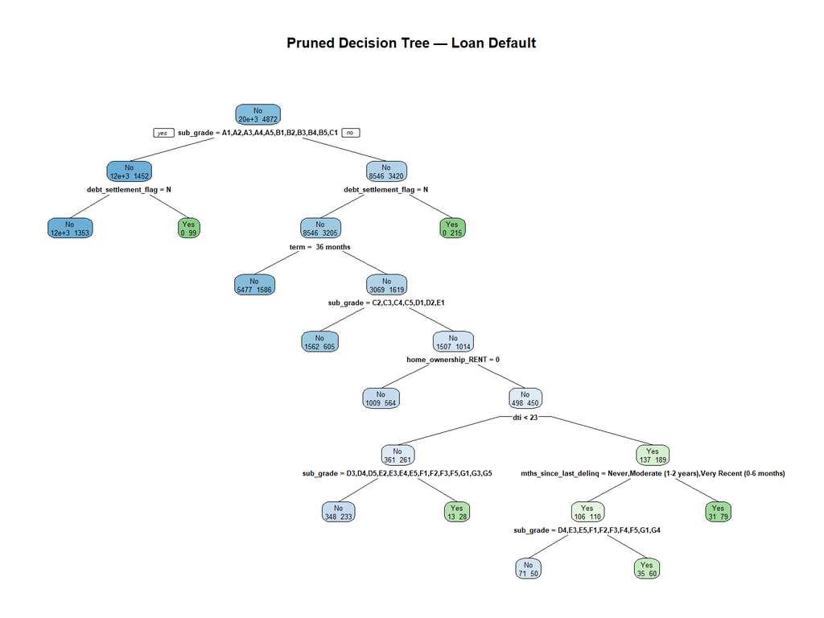

```r
# Prune model using best cp
pruned.loan.tree <- prune(cv_tree, cp = best_cp)

# Plot pruned tree
rpart.plot(
  pruned.loan.tree,
  extra = 1,
  fallen.leaves = FALSE,
  main = "Pruned Decision Tree — Loan Default"
)
```

This decision tree model for loan default prediction follows a systematic approach to build an optimal classifier. Initially, the algorithm grows a complex tree using entropy-based information gain to recursively split the data at points that best separate defaulters from non-defaulters, with a very small complexity parameter (0.0001) allowing extensive branching. However, to prevent overfitting and improve generalization, the model employs cross-validation to identify the optimal complexity parameter (0.001574) that minimizes prediction error on unseen data. The final pruned tree removes unnecessary branches that don't contribute meaningfully to predictive accuracy, resulting in a simpler, more interpretable model that balances complexity with performance—essentially creating a set of if-then rules that can effectively classify loan applicants based on their risk of default.

# Holdout Performance

```r
# Predicted class labels
tree.pred.class <- predict(pruned.loan.tree, newdata = holdout.df, type = "class")
# Confusion Matrix
confusionMatrix(
  tree.pred.class,
  holdout.df$loan_default,
  positive = "Yes"
)
```

```
## Confusion Matrix and Statistics
##
##           Reference
## Prediction    No   Yes
##        No  63293 14077
##        Yes   399  1464
##
##                Accuracy : 0.8173
##                  95% CI : (0.8146, 0.82)
##     No Information Rate : 0.8039
##     P-Value [Acc > NIR] : < 2.2e-16
##
##                   Kappa : 0.1318
##
##  Mcnemar's Test P-Value : < 2.2e-16
##
##             Sensitivity : 0.09420
##             Specificity : 0.99374
##          Pos Pred Value : 0.78583
##          Neg Pred Value : 0.81806
##              Prevalence : 0.19614
##          Detection Rate : 0.01848
##    Detection Prevalence : 0.02351
##       Balanced Accuracy : 0.54397
##
##        'Positive' Class : Yes
##
```

```r
# --- Compute and print AUC ---
# Get predicted probabilities instead of classes
tree.pred.prob <- predict(pruned.loan.tree, newdata = holdout.df, type = "prob")[, "Yes"]

library(pROC)
roc_obj <- roc(holdout.df$loan_default, tree.pred.prob, levels = c("No", "Yes"))
auc_value <- auc(roc_obj)
print(paste("AUC:", round(auc_value, 4)))
```

```
## [1] "AUC: 0.6859"
```

The pruned decision tree demonstrates mixed performance on the holdout dataset, with an overall accuracy of 81.73% that slightly exceeds the no-information rate of 80.39%. However, the model exhibits a significant class imbalance issue, showing very high specificity (99.37%) but extremely low sensitivity (9.42%), meaning it correctly identifies most non-defaulters but fails to detect the majority of actual loan defaults. This conservative prediction pattern results in a low Kappa statistic (0.1318) and poor balanced accuracy (54.40%), indicating limited practical utility for identifying high-risk borrowers. The AUC of 0.6859 suggests moderate discriminatory ability—better than random chance (0.5) but far from excellent performance (>0.8)—reflecting the model's struggle to effectively separate defaulters from non-defaulters. While the high positive predictive value (78.58%) means that loans flagged as risky are likely to default, the model's failure to identify most actual defaults (sensitivity of only 9.42%) severely limits its effectiveness as a risk management tool, potentially exposing the lender to significant undetected default risk.